# LET Youth CFA

# Create the Models, As only one factor

```r
one.factor = 'LET =~ LET_1 +  LET_2  +LET_3  + LET_4 + LET_5 + LET_6
'
```

Two Factor, Positive and Nagative Model

```r
first.model= ' Negative =~ LET_1 +  LET_3  + LET_5
             Positive =~   LET_2 + LET_4 + LET_6
'
```

Second order models

```r
second.model = ' Negative =~ LET_1 +  LET_3  + LET_5
              Positive =~   LET_2 + LET_4 + LET_6
              LET =~ NA*Positive + Negative
'

alternative.model  = 'Negative =~ LET_1 +  LET_3  + LET_5
              Positive =~ LET_2 + LET_4 + LET_6
              LET =~ NA*Positive + Negative
              LET~~1*LET
'
```

Bifactor Models (similar to Models 6, 7 & 8 in Marsh, Scalas & Nagengast, 2010)

```r
bifactor.model = 'Negative =~ LET_1 +  LET_3  + LET_5
              Positive =~   LET_2 + LET_4 + LET_6
              Life Satisfaction =~ LET_1 +  LET_2  + LET_3 + LET_4 + LET_5 + LET_6
'
```

Bifactor only with Negative questions protioned out (like model 7 in Marsh, Scalas & Nagengast, 2010)

```r
bifactor.negative.model = 'Negative =~ LET_1 +  LET_3  + LET_5
                        LET =~ LET_1 +  LET_2  + LET_3 + LET_4 + LET_5 + LET_6
'
```

Bifactor only with Positive questions protioned out (like model 8 in Marsh, Scalas & Nagengast, 2010)

```r
bifactor.positive.model = 'Positive =~   LET_2 + LET_4 + LET_6
                        LET =~ LET_1 +  LET_2  + LET_3 + LET_4 + LET_5 + LET_6
'
```

Alternative method of writing bifactor model

```r
bifactor.model1 = 'LET =~ LET_1 +  LET_2  + LET_3 + LET_4 + LET_5 + LET_6
                Negative =~ LET_1 +  LET_3  + LET_5
                Positive =~   LET_2 + LET_4 + LET_6
                LET ~~ 0*Negative
                LET ~~ 0*Positive
                Negative~~0*Positive
'
```

Running the models

```r
one.fit=cfa(one.factor, data=LET, missing = "fiml", std.lv = T)
```

```
## Found more than one class "Model" in cache; using the first, from namespace 'lavaan'
```

```r
two.fit=cfa(first.model, data=LET, missing = "fiml", std.lv = T)
second.fit=cfa(second.model, data=LET, missing = "fiml", std.lv = T)
alt.fit=cfa(alternative.model, data=LET, missing = "fiml", std.lv = T)
bifactor.fit=cfa(bifactor.model, data=LET, missing = "fiml", orthogonal = TRUE, std.lv = T)
bifactor.fit1=cfa(bifactor.model1, data=LET, missing = "fiml", orthogonal = TRUE, std.lv = T)
bifactor.negative.fit=cfa(bifactor.negative.model, missing = "fiml", data=LET, orthogonal = TRUE, std.lv = T)
bifactor.positive.fit=cfa(bifactor.positive.model, missing = "fiml", data=LET, orthogonal = TRUE, std.lv = T)
```

Create pictures of models

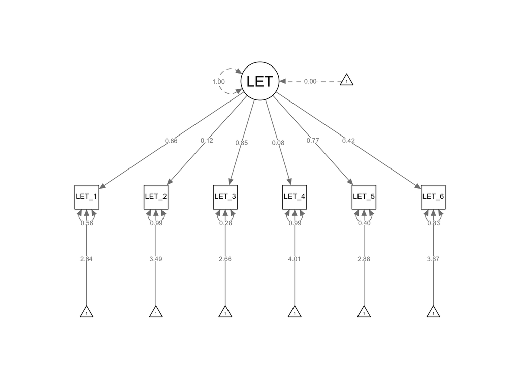

```r
#One Factor
semPaths(one.fit, whatLabels = "std", layout = "tree", title=T)
```

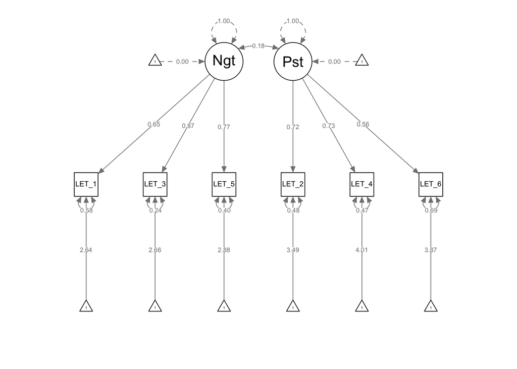

```r
#Two Factors Positive and Nagative
semPaths(two.fit, whatLabels = "std", layout = "tree")
```

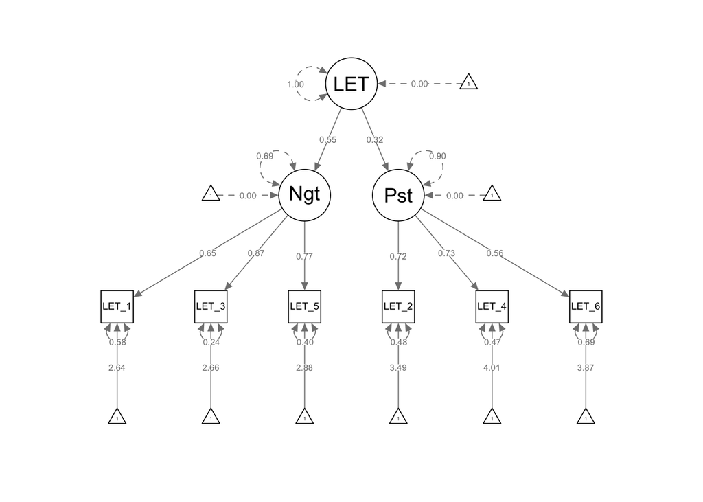

```r
#Second order factors
semPaths(second.fit, whatLabels = "std", layout = "tree")
```

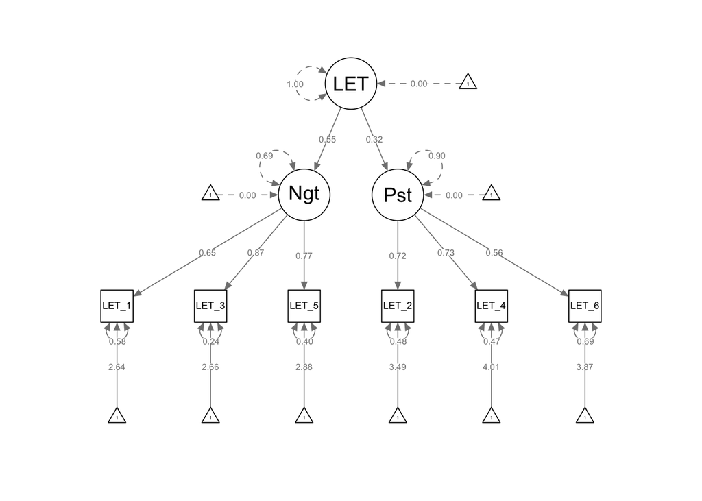

```r
semPaths(alt.fit, whatLabels = "std", layout = "tree")
```

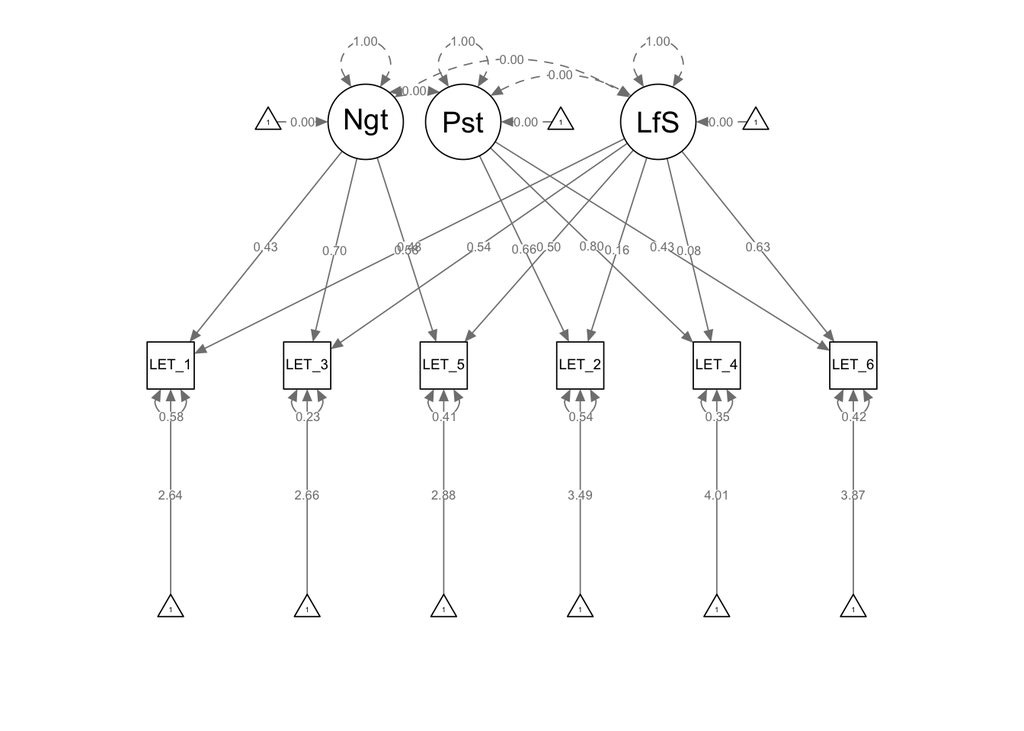

```r
#Bifactor Models (similar to Models 6, 7 & 8 in Marsh, Scalas & Nagengast, 2010)
semPaths(bifactor.fit, whatLabels = "std", layout = "tree")
```

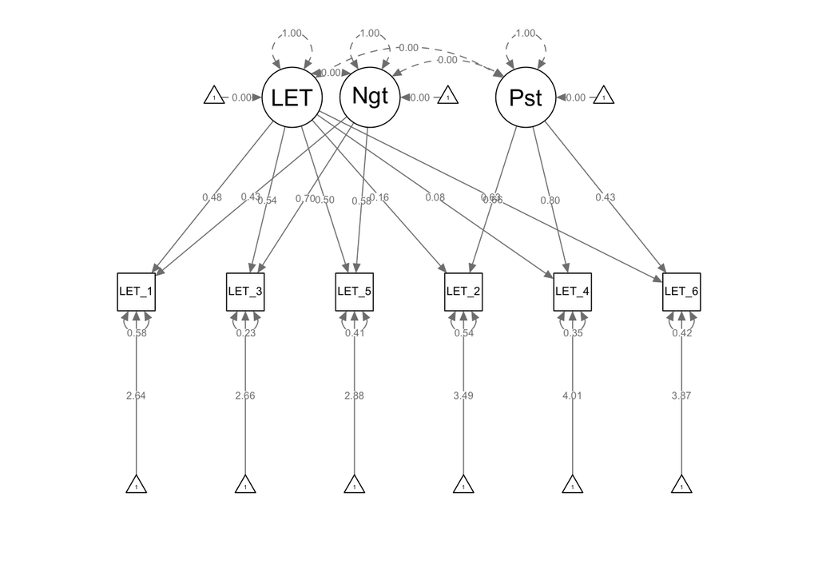

```r
semPaths(bifactor.fit1, whatLabels = "std", layout = "tree")
```

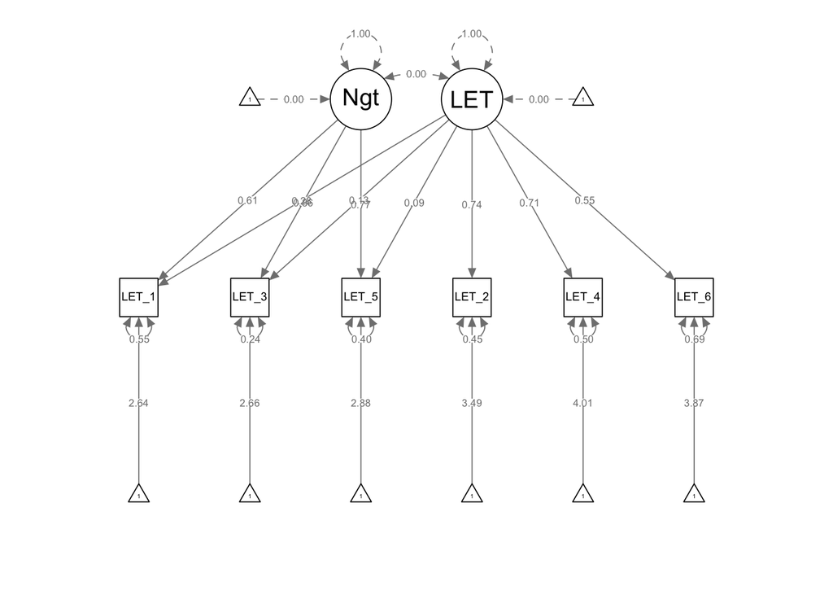

```r
#Bifactor only with Negative questions protioned out (like model 7 in Marsh, Scalas & Nagengast, 2010)
semPaths(bifactor.negative.fit, whatLabels = "std", layout = "tree")
```